# Analisis regresi CO terhadap AQI

Author

Indah Dzulkharifah

# Package

```r
library(dLagM)
library(dynlm)
library(MLmetrics)
library(lmtest)
library(car)
library("readxl")
```

# Import Data

```r
data <- read_excel("C:/Users/USER/OneDrive/Documents/Semester 5/MPDW/DATA P4.xlsx")
str(data)
```

```
tibble [72 × 3] (S3: tbl_df/tbl/data.frame)
 $ t : num [1:72] 1 2 3 4 5 6 7 8 9 10 ...
 $ Yt: num [1:72] 30.2 28.2 26.6 25 26 26 26 24 23 24 ...
 $ Xt: num [1:72] 19860268 19760132 19860268 20194054 2052784 ...
```

```r
data
```

```
# A tibble: 72 × 3
       t    Yt       Xt
   <dbl> <dbl>    <dbl>
 1     1  30.2 19860268
 2     2  28.2 19760132
 3     3  26.6 19860268
 4     4  25   20194054
 5     5  26    2052784
 6     6  26   20861626
 7     7  26   20861626
 8     8  24    2052784
 9     9  23    2002716
10    10  24   19693375
# ℹ 62 more rows
```

# Pembagian Data

```r
#SPLIT DATA
train<-data[1:58,]
test<-data[59:72,]
```

```r
#data time series
train.ts<-ts(train)
test.ts<-ts(test)
data.ts<-ts(data)
```

# Model Koyck

$$y_t=a(1−λ)+β_0X_t+β_1Z_t+λY_{t-1}+V_t$$

```r
#MODEL KOYCK
model.koyck <- koyckDlm(x = train$Xt, y = train$Yt)
summary(model.koyck)
```

```
Call:
"Y ~ (Intercept) + Y.1 + X.t"

Residuals:
     Min       1Q   Median       3Q      Max
-2.23982 -0.75773  0.06513  0.61497  2.02588

Coefficients:
              Estimate Std. Error t value Pr(>|t|)
(Intercept)  2.588e+00  2.606e+00   0.993    0.325
Y.1          9.114e-01  6.296e-02  14.476   <2e-16 ***
X.t         -2.210e-08  1.101e-07  -0.201    0.842
---
Signif. codes:  0 '***' 0.001 '**' 0.01 '*' 0.05 '.' 0.1 ' ' 1

Residual standard error: 0.972 on 54 degrees of freedom
Multiple R-Squared: 0.8105, Adjusted R-squared: 0.8034
Wald test: 115.8 on 2 and 54 DF,  p-value: < 2.2e-16

Diagnostic tests:
NULL

                            alpha          beta       phi
Geometric coefficients:  29.21999 -2.209836e-08 0.9114347
```

```r
AIC(model.koyck)
```

```
[1] 163.4434
```

```r
BIC(model.koyck)
```

```
[1] 171.6156
```

# Peramalan dan Akurasi

Berikut adalah hasil peramalan y untuk 14 periode kedepan menggunakan model koyck

```r
fore.koyck <- forecast(model = model.koyck, x=test$Xt, h=14)
fore.koyck
```

```
$forecasts
 [1] 23.11568 23.22850 23.33132 23.42873 23.51750 23.59842 23.67217 23.73939
 [9] 23.80065 23.85280 23.89664 23.93292 23.96229 23.98906

$call
forecast.koyckDlm(model = model.koyck, x = test$Xt, h = 14)

attr(,"class")
[1] "forecast.koyckDlm" "dLagM"
```

```r
mape.koyck <- MAPE(fore.koyck$forecasts, test$Yt)
mape.koyck #data test
```

```
[1] 0.1277867
```

```r
#akurasi data training
GoF(model.koyck)
```

```
             n       MAE          MPE       MAPE      sMAPE     MASE       MSE
model.koyck 57 0.7431624 -0.001193775 0.02780099 0.02768946 1.118739 0.8951181
                 MRAE    GMRAE
model.koyck 964209780 11962.43
```

# Regression with Distributed Lag

## Pemodelan (Lag=2)

```r
model.dlm <- dlm(x = train$Xt,y = train$Yt , q = 2)
summary(model.dlm)
```

```
Call:
lm(formula = model.formula, data = design)

Residuals:
    Min      1Q  Median      3Q     Max
-4.1989 -1.5854 -0.1443  0.9760  4.8959

Coefficients:
              Estimate Std. Error t value Pr(>|t|)
(Intercept)  2.772e+01  8.420e-01  32.919   <2e-16 ***
x.t         -2.023e-08  3.523e-08  -0.574    0.568
x.1         -5.231e-09  3.535e-08  -0.148    0.883
x.2         -2.250e-08  3.523e-08  -0.639    0.526
---
Signif. codes:  0 '***' 0.001 '**' 0.01 '*' 0.05 '.' 0.1 ' ' 1

Residual standard error: 2.254 on 52 degrees of freedom
Multiple R-squared:  0.01432,   Adjusted R-squared:  -0.04255
F-statistic: 0.2517 on 3 and 52 DF,  p-value: 0.8597

AIC and BIC values for the model:
       AIC      BIC
1 255.7743 265.9011
```

```r
AIC(model.dlm)
```

```
[1] 255.7743
```

```r
BIC(model.dlm)
```

```
[1] 265.9011
```

$$\hat{Y_t}=27.72-0.00000002023X_t-0.000000005231X_{t-1}-0.00000002250X_{t-2}$$

# Peramalan dan Akurasi

Berikut merupakan hasil peramalan y untuk 14 periode kedepan

```r
fore.dlm <- forecast(model = model.dlm, x=test$Xt, h=14)
fore.dlm
```

```
$forecasts
 [1] 26.77034 26.77796 26.78346 26.79435 26.79522 26.79898 26.79898 26.79898
 [9] 26.79898 26.79560 26.79135 26.78335 26.77534 26.77071

$call
forecast.dlm(model = model.dlm, x = test$Xt, h = 14)

attr(,"class")
[1] "forecast.dlm" "dLagM"
```

```r
mape.dlm <- MAPE(fore.dlm$forecasts, test$Yt)
mape.dlm
```

```
[1] 0.2311905
```

```r
#akurasi data training
GoF(model.dlm)
```

```
           n      MAE          MPE       MAPE      sMAPE     MASE      MSE
model.dlm 56 1.667033 -0.006312046 0.06137396 0.06130761 2.575473 4.715948
                MRAE    GMRAE
model.dlm 6401461184 33874.37
```

# Lag Optimum

```r
#penentuan lag optimum
finiteDLMauto(formula = Yt ~ Xt,
              data = data.frame(train), q.min = 1, q.max = 10,
              model.type = "dlm", error.type = "AIC", trace = TRUE)
```

```
   q - k    MASE      AIC      BIC    GMRAE   MBRAE R.Adj.Sq    Ljung-Box
10    10 2.70372 227.6558 251.9814 83270.30 0.57874 -0.11612 2.506006e-09
9      9 2.74551 232.2132 254.9151 68225.67 1.02409 -0.10006 3.699237e-09
8      8 2.84058 239.0482 260.0805 59965.75 0.78379 -0.10530 4.694671e-09
7      7 2.83078 245.1257 264.4439 42989.24 1.19435 -0.13215 7.142960e-10
6      6 2.66179 248.1984 265.7596 25666.03 0.56424 -0.13231 1.220232e-10
5      5 2.69508 250.2685 266.0308 38299.67 1.51045 -0.11243 4.255007e-11
4      4 2.71944 252.2756 266.1985 47780.29 0.76805 -0.09340 1.992506e-11
3      3 2.69094 254.3684 266.4124 40956.34 0.99858 -0.06526 1.525569e-11
2      2 2.57547 255.7743 265.9011 33874.37 0.98512 -0.04255 9.764856e-12
1      1 2.50535 257.9461 266.1183 23699.43 0.99035 -0.03161 1.380240e-11
```

Berdasarkan output tersebut, lag optimum didapatkan ketika lag=10. Selanjutnya dilakukan pemodelan untuk lag=10

```r
#model dlm dengan lag optimum
model.dlm2 <- dlm(x = train$Xt,y = train$Yt , q = 10)
summary(model.dlm2)
```

```
Call:
lm(formula = model.formula, data = design)

Residuals:
   Min     1Q Median     3Q    Max
-3.840 -1.477 -0.181  1.003  4.968

Coefficients:
              Estimate Std. Error t value Pr(>|t|)
(Intercept)  3.154e+01  2.072e+00  15.226   <2e-16 ***
x.t         -4.179e-08  4.165e-08  -1.003    0.322
x.1         -2.003e-08  4.155e-08  -0.482    0.633
x.2         -2.413e-08  4.106e-08  -0.588    0.560
x.3         -9.082e-10  4.107e-08  -0.022    0.982
x.4         -7.586e-09  4.241e-08  -0.179    0.859
x.5         -1.731e-08  4.052e-08  -0.427    0.672
x.6         -1.749e-08  4.166e-08  -0.420    0.677
x.7         -2.816e-08  4.209e-08  -0.669    0.508
x.8         -5.268e-08  4.211e-08  -1.251    0.219
x.9         -4.559e-08  4.117e-08  -1.107    0.275
x.10        -4.450e-08  4.135e-08  -1.076    0.289
---
Signif. codes:  0 '***' 0.001 '**' 0.01 '*' 0.05 '.' 0.1 ' ' 1

Residual standard error: 2.283 on 36 degrees of freedom
Multiple R-squared:  0.1451,    Adjusted R-squared:  -0.1161
F-statistic: 0.5555 on 11 and 36 DF,  p-value: 0.8511

AIC and BIC values for the model:
       AIC      BIC
1 227.6558 251.9814
```

```r
AIC(model.dlm2)
```

```
[1] 227.6558
```

```r
BIC(model.dlm2)
```

```
[1] 251.9814
```

Dari hasil tersebut hanya intercept yang berpengaruh signifikan terhadap taraf nyata 5%. Adapun keseluruhan model yang terbentuk adalah

$$\hat{Y_t}=31.54-0.00000004179X_t+...-0.00000004450X_{t-10}$$

Adapun hasil peramalan 14 periode kedepan menggunakan model tersebut adalah sebagai berikut

```r
#peramalan dan akurasi
fore.dlm2 <- forecast(model = model.dlm2, x=test$Xt, h=14)

#akurasi data test
mape.dlm2<- MAPE(fore.dlm2$forecasts, test$Yt)
mape.dlm2
```

```
[1] 0.236925
```

```r
#akurasi data training
GoF(model.dlm2)
```

```
            n      MAE          MPE       MAPE      sMAPE     MASE      MSE
model.dlm2 48 1.610725 -0.005103826 0.05851418 0.05850234 2.703717 3.909011
                 MRAE   GMRAE
model.dlm2 7880533531 83270.3
```

# Model Autoregressive

## Pemodelan

Dengan p adalah integer yang mewakili panjang lag yang terbatas dan q adalah integer yang merepresentasikan ordo dari proses autoregressive.

```r
model.ardl1 <- ardlDlm(x = train$Xt, y = train$Yt, p = 1 , q = 1)
summary(model.ardl1)
```

```
Time series regression with "ts" data:
Start = 2, End = 58

Call:
dynlm(formula = as.formula(model.text), data = data, start = 1)

Residuals:
     Min       1Q   Median       3Q      Max
-2.04681 -0.70219  0.08664  0.51631  2.21090

Coefficients:
              Estimate Std. Error t value Pr(>|t|)
(Intercept)  2.346e+00  1.678e+00   1.398    0.168
X.t         -7.095e-09  1.505e-08  -0.471    0.639
X.1         -2.031e-09  1.504e-08  -0.135    0.893
Y.1          9.138e-01  6.020e-02  15.178   <2e-16 ***
---
Signif. codes:  0 '***' 0.001 '**' 0.01 '*' 0.05 '.' 0.1 ' ' 1

Residual standard error: 0.9721 on 53 degrees of freedom
Multiple R-squared:  0.814, Adjusted R-squared:  0.8034
F-statistic: 77.29 on 3 and 53 DF,  p-value: < 2.2e-16
```

```r
AIC(model.ardl1)
```

```
[1] 164.3844
```

```r
BIC(model.ardl1)
```

```
[1] 174.5996
```

```r
model.ardl1 <- ardlDlm(formula = Yt ~ Xt,
                         data = train,p = 1 , q = 1)
summary(model.ardl1)
```

```
Time series regression with "ts" data:
Start = 2, End = 58

Call:
dynlm(formula = as.formula(model.text), data = data)

Residuals:
     Min       1Q   Median       3Q      Max
-2.04681 -0.70219  0.08664  0.51631  2.21090

Coefficients:
              Estimate Std. Error t value Pr(>|t|)
(Intercept)  2.346e+00  1.678e+00   1.398    0.168
Xt.t        -7.095e-09  1.505e-08  -0.471    0.639
Xt.1        -2.031e-09  1.504e-08  -0.135    0.893
Yt.1         9.138e-01  6.020e-02  15.178   <2e-16 ***
---
Signif. codes:  0 '***' 0.001 '**' 0.01 '*' 0.05 '.' 0.1 ' ' 1

Residual standard error: 0.9721 on 53 degrees of freedom
Multiple R-squared:  0.814, Adjusted R-squared:  0.8034
F-statistic: 77.29 on 3 and 53 DF,  p-value: < 2.2e-16
```

```r
AIC(model.ardl1)
```

```
[1] 164.3844
```

```r
BIC(model.ardl1)
```

```
[1] 174.5996
```

Hasil di atas menunjukkan bahwa hanya $Y_{t-1}< 0.05$ yang berpengaruh signifikan terhadap $y_t$. Model keseluruhannya adalah sebagai berikut:

$$\hat{Y}=2.346-0.000000007095X_t-0.000000002031X_{t-1}+0.9138Y_{t-1}$$

# Peramalan dan Akurasi

```r
fore.ardl1 <- forecast(model = model.ardl1, x=test$Xt, h=14)
fore.ardl1
```

```
$forecasts
 [1] 23.18240 23.35178 23.50723 23.65045 23.78167 23.90157 24.01113 24.11124
 [9] 24.20271 24.28512 24.35889 24.42478 24.48346 24.53675

$call
forecast.ardlDlm(model = model.ardl1, x = test$Xt, h = 14)

attr(,"class")
[1] "forecast.ardlDlm" "dLagM"
```

Data di atas merupakan hasil peramalan untuk 14 periode ke depan menggunakan Model Autoregressive dengan p=1 dan q=1

```r
mape.ardl1 <- MAPE(fore.ardl1$forecasts, test$Yt)
mape.ardl1
```

```
[1] 0.1337824
```

```r
#akurasi data training
GoF(model.ardl1)
```

```
             n       MAE          MPE       MAPE      sMAPE     MASE       MSE
model.ardl1 57 0.7165855 -0.001205637 0.02675399 0.02665491 1.078731 0.8786409
                 MRAE    GMRAE
model.ardl1 715341446 8736.633
```

# Lag Optimum

```r
#penentuan lag optimum
model.ardl.opt <- ardlBoundOrders(data = data.frame(data), ic = "AIC",
                                  formula = Yt ~ Xt )
model.ardl.opt
```

```
$p
  Xt
1 15

$q
[1] 3

$Stat.table
          q = 1    q = 2    q = 3    q = 4    q = 5    q = 6    q = 7    q = 8
p = 1  174.7516 172.8180 173.1649 163.8004 163.5403 163.7088 156.8568 156.6498
p = 2  172.3159 172.4607 172.7080 163.9520 163.7715 164.1710 158.4912 158.2579
p = 3  172.2158 172.2158 174.0699 164.7002 164.5780 165.0383 159.9014 159.6204
p = 4  164.5473 166.5095 166.5095 166.2324 165.9620 166.4407 161.6031 161.2014
p = 5  162.2073 164.2071 164.9948 164.9948 166.2521 166.4499 160.9645 160.5548
p = 6  161.8029 163.7518 165.0291 166.6796 166.6796 168.0648 162.8561 162.5070
p = 7  158.9508 160.1151 161.7302 162.1155 162.8270 162.8270 164.7555 164.2439
p = 8  160.2994 161.1914 162.6414 162.6280 164.1961 165.2068 165.2068 165.9971
p = 9  159.3581 158.7317 160.2468 160.5603 162.5476 164.1162 165.4403 165.4403
p = 10 159.4801 157.9325 158.7951 159.6008 161.5951 161.8392 163.1824 165.1814
p = 11 158.5036 154.9114 155.0360 154.5572 156.5548 158.0606 159.4170 161.1446
p = 12 153.1525 150.3375 151.4880 150.3886 152.3837 154.3515 155.4925 157.0461
p = 13 147.1345 146.5971 147.8549 147.0433 148.8917 150.8874 152.8489 154.7217
p = 14 146.9327 146.5702 147.8942 146.7563 148.6002 150.3992 152.3920 154.2220
p = 15 139.7840 139.0861 138.7767 139.3180 141.0561 142.7649 144.6848 146.4781
          q = 9   q = 10   q = 11   q = 12   q = 13   q = 14   q = 15
p = 1  154.8414 153.4913 149.4811 150.4242 150.4774 148.2863 146.7174
p = 2  156.4674 154.7216 151.1278 151.8856 151.9731 150.2269 148.6561
p = 3  157.7484 156.2589 153.0522 153.8415 153.9700 152.2206 150.5052
p = 4  159.6538 158.1259 155.0511 155.8255 155.9671 154.2091 152.4084
p = 5  159.6423 156.9899 154.4231 155.4800 155.7164 154.9411 152.0029
p = 6  161.5594 158.5571 156.1119 157.1846 157.2449 156.2242 153.8303
p = 7  163.4484 160.4856 158.0749 159.1318 159.2412 158.2201 155.7054
p = 8  165.2966 162.4413 160.0079 161.0233 160.9480 160.1283 157.7030
p = 9  167.2921 164.4413 162.0000 163.0131 162.9391 162.0133 159.3135
p = 10 165.1814 165.2692 163.3518 164.4200 163.9966 162.9123 160.2553
p = 11 160.7864 160.7864 158.5357 159.2318 159.3707 159.2232 157.2936
p = 12 155.5593 157.5521 157.5521 158.3999 159.1930 159.0382 156.2787
p = 13 156.4670 156.9595 157.5642 157.5642 159.5608 159.9261 157.8914
p = 14 155.8741 157.3173 158.1461 159.8974 159.8974 161.8784 159.8375
p = 15 148.1546 150.0800 151.6113 153.0491 154.5887 154.5887 155.8848

$min.Stat
[1] 138.7767
```

```r
min_p=c()
for(i in 1:6){
  min_p[i]=min(model.ardl.opt$Stat.table[[i]])
}
q_opt=which(min_p==min(min_p, na.rm = TRUE))
p_opt=which(model.ardl.opt$Stat.table[[q_opt]] ==
              min(model.ardl.opt$Stat.table[[q_opt]], na.rm = TRUE))
data.frame("q_optimum" = q_opt, "p_optimum" = p_opt,
           "AIC"=model.ardl.opt$min.Stat)
```

```
  q_optimum p_optimum      AIC
1         3        15 138.7767
```

Dari tabel di atas, dapat terlihat bahwa nilai AIC terendah didapat ketika $p=15$ dan $q=3$, yaitu sebesar `138.7767`. Artinya, model autoregressive optimum didapat ketika $p=15$ dan $q=3$.

Selanjutnya dapat dilakukan pemodelan dengan nilai $p$ dan $q$ optimum seperti inisialisasi di langkah sebelumnya.

```r
model.ardl2 <- ardlDlm(x = train$Xt, y = train$Yt, p = 15 , q = 3)
summary(model.ardl2)
```

```
Time series regression with "ts" data:
Start = 16, End = 58

Call:
dynlm(formula = as.formula(model.text), data = data, start = 1)

Residuals:
     Min       1Q   Median       3Q      Max
-1.19640 -0.34768  0.00642  0.31778  1.59707

Coefficients:
              Estimate Std. Error t value Pr(>|t|)
(Intercept)  5.590e+00  2.426e+00   2.304   0.0306 *
X.t          4.878e-09  1.672e-08   0.292   0.7731
X.1          9.649e-09  1.565e-08   0.616   0.5436
X.2         -1.545e-08  1.565e-08  -0.987   0.3338
X.3          2.055e-10  1.588e-08   0.013   0.9898
X.4         -7.786e-09  1.540e-08  -0.506   0.6178
X.5         -8.770e-10  1.543e-08  -0.057   0.9552
X.6          1.321e-08  1.625e-08   0.813   0.4245
X.7         -5.089e-09  1.596e-08  -0.319   0.7528
X.8         -1.224e-08  1.572e-08  -0.779   0.4440
X.9         -2.072e-09  1.537e-08  -0.135   0.8939
X.10        -1.431e-08  1.509e-08  -0.948   0.3528
X.11        -6.128e-09  1.515e-08  -0.404   0.6897
X.12        -3.856e-08  1.489e-08  -2.590   0.0164 *
X.13         2.643e-09  1.714e-08   0.154   0.8788
X.14        -2.270e-08  1.506e-08  -1.507   0.1455
X.15        -1.329e-08  1.655e-08  -0.803   0.4304
Y.1          1.273e+00  2.057e-01   6.190 2.58e-06 ***
Y.2         -4.411e-02  3.365e-01  -0.131   0.8968
Y.3         -3.827e-01  1.931e-01  -1.982   0.0596 .
---
Signif. codes:  0 '***' 0.001 '**' 0.01 '*' 0.05 '.' 0.1 ' ' 1

Residual standard error: 0.7419 on 23 degrees of freedom
Multiple R-squared:  0.9387,    Adjusted R-squared:  0.888
F-statistic: 18.53 on 19 and 23 DF,  p-value: 1.038e-09
```

```r
AIC(model.ardl2)
```

```
[1] 111.4491
```

```r
BIC(model.ardl2)
```

```
[1] 148.4343
```

```r
model.ardl2 <- ardlDlm(formula = Yt ~ Xt,
                         data = train,p = 15 , q = 3)
summary(model.ardl2)
```

```
Time series regression with "ts" data:
Start = 16, End = 58

Call:
dynlm(formula = as.formula(model.text), data = data)

Residuals:
     Min       1Q   Median       3Q      Max
-1.19640 -0.34768  0.00642  0.31778  1.59707

Coefficients:
              Estimate Std. Error t value Pr(>|t|)
(Intercept)  5.590e+00  2.426e+00   2.304   0.0306 *
Xt.t         4.878e-09  1.672e-08   0.292   0.7731
Xt.1         9.649e-09  1.565e-08   0.616   0.5436
Xt.2        -1.545e-08  1.565e-08  -0.987   0.3338
Xt.3         2.055e-10  1.588e-08   0.013   0.9898
Xt.4        -7.786e-09  1.540e-08  -0.506   0.6178
Xt.5        -8.770e-10  1.543e-08  -0.057   0.9552
Xt.6         1.321e-08  1.625e-08   0.813   0.4245
Xt.7        -5.089e-09  1.596e-08  -0.319   0.7528
Xt.8        -1.224e-08  1.572e-08  -0.779   0.4440
Xt.9        -2.072e-09  1.537e-08  -0.135   0.8939
Xt.10       -1.431e-08  1.509e-08  -0.948   0.3528
Xt.11       -6.128e-09  1.515e-08  -0.404   0.6897
Xt.12       -3.856e-08  1.489e-08  -2.590   0.0164 *
Xt.13        2.643e-09  1.714e-08   0.154   0.8788
Xt.14       -2.270e-08  1.506e-08  -1.507   0.1455
Xt.15       -1.329e-08  1.655e-08  -0.803   0.4304
Yt.1         1.273e+00  2.057e-01   6.190 2.58e-06 ***
Yt.2        -4.411e-02  3.365e-01  -0.131   0.8968
Yt.3        -3.827e-01  1.931e-01  -1.982   0.0596 .
---
Signif. codes:  0 '***' 0.001 '**' 0.01 '*' 0.05 '.' 0.1 ' ' 1

Residual standard error: 0.7419 on 23 degrees of freedom
Multiple R-squared:  0.9387,    Adjusted R-squared:  0.888
F-statistic: 18.53 on 19 and 23 DF,  p-value: 1.038e-09
```

```r
AIC(model.ardl2)
```

```
[1] 111.4491
```

```r
BIC(model.ardl2)
```

```
[1] 148.4343
```

Hasil di atas menunjukkan bahwa intercept, $X_{t-12}$, dan $Y_{t-1}$ memiliki p-value < 0.05 yang berarti intercept, $X_{t-12}$, dan $Y_{t-1}$ berpengaruh signifikan terhadap $y_t$. Model keseluruhannya adalah sebagai berikut:

$$\hat{Y}=5.590+0.000000004878X_t+....-0.00000001329X_{t-15}+1.273Y_{t-1}-....-0.3827Y_{t-3}$$

# Peramalan dan Akurasi

```r
fore.ardl2 <- forecast(model = model.ardl2, x=test$Xt, h=14)
fore.ardl2
```

```
$forecasts
 [1] 21.77409 20.69625 20.63206 21.08992 22.55785 24.35237 26.54508 28.82152
 [9] 30.25169 31.18327 31.03612 30.03072 28.40927 26.45801

$call
forecast.ardlDlm(model = model.ardl2, x = test$Xt, h = 14)

attr(,"class")
[1] "forecast.ardlDlm" "dLagM"
```

```r
mape.ardl2 <- MAPE(fore.ardl2$forecasts, test$Yt)
mape.ardl2
```

```
[1] 0.1872252
```

```r
#akurasi data training
GoF(model.ardl2)
```

```
             n       MAE           MPE       MAPE      sMAPE      MASE
model.ardl2 43 0.4181729 -0.0003830515 0.01529232 0.01530253 0.7318025
                  MSE       MRAE    GMRAE
model.ardl2 0.2944103 1633055688 24622.78
```

## Pemodelan DLM & ARDL dengan Library `dynlm`

Pemodelan regresi dengan peubah *lag* tidak hanya dapat dilakukan dengan fungsi pada *packages* `dLagM` , tetapi terdapat *packages* `dynlm` yang dapat digunakan. Fungsi `dynlm` secara umum adalah sebagai berikut.

```r
dynlm(formula, data, subset, weights, na.action, method = "qr",
  model = TRUE, x = FALSE, y = FALSE, qr = TRUE, singular.ok = TRUE,
  contrasts = NULL, offset, start = NULL, end = NULL, ...)
```

Untuk menentukan `formula` model yang akan digunakan, tersedia fungsi tambahan yang memungkinkan spesifikasi dinamika (melalui `d()` dan `L()`) atau pola linier/siklus dengan mudah (melalui `trend()`, `season()`, dan `harmon()`). Semua fungsi formula baru mengharuskan argumennya berupa objek deret waktu (yaitu, `"ts"` atau `"zoo"`).

`L()` : fungsi untuk mengambil nilai lag dari suatu variabel.

`L(Xt)`= Xt pada periode sebelumnya (lag ke-1).

`L(Xt, 2)` = Xt pada dua periode sebelumnya (lag ke-2).

```r
#sama dengan model dlm q=1
cons_lm1 <- dynlm(Yt ~ Xt+L(Xt),data = train.ts)

#sama dengan model ardl p=1 q=0
cons_lm2 <- dynlm(Yt ~ Xt+L(Yt),data = train.ts)

#sama dengan ardl p=1 q=1
cons_lm3 <- dynlm(Yt ~ Xt+L(Xt)+L(Yt),data = train.ts)

#sama dengan dlm p=2
cons_lm4 <- dynlm(Yt ~ Xt+L(Xt)+L(Xt,2),data = train.ts)
```

## Ringkasan Model

Berikut adalah ringkasan hasil estimasi dari masing-masing model:

```r
summary(cons_lm1)
```

```
Time series regression with "ts" data:
Start = 2, End = 58

Call:
dynlm(formula = Yt ~ Xt + L(Xt), data = train.ts)

Residuals:
   Min     1Q Median     3Q    Max
-4.352 -1.230 -0.228  1.253  5.074

Coefficients:
              Estimate Std. Error t value Pr(>|t|)
(Intercept)  2.740e+01  6.897e-01  39.725   <2e-16 ***
Xt          -1.595e-08  3.445e-08  -0.463    0.645
L(Xt)       -6.837e-09  3.445e-08  -0.198    0.843
---
Signif. codes:  0 '***' 0.001 '**' 0.01 '*' 0.05 '.' 0.1 ' ' 1

Residual standard error: 2.227 on 54 degrees of freedom
Multiple R-squared:  0.005232,  Adjusted R-squared:  -0.03161
F-statistic: 0.142 on 2 and 54 DF,  p-value: 0.8679
```

```r
summary(cons_lm2)
```

```
Time series regression with "ts" data:
Start = 2, End = 58

Call:
dynlm(formula = Yt ~ Xt + L(Yt), data = train.ts)

Residuals:
    Min      1Q  Median      3Q     Max
-2.0642 -0.7199  0.0744  0.5035  2.1940

Coefficients:
              Estimate Std. Error t value Pr(>|t|)
(Intercept)  2.317e+00  1.649e+00   1.405    0.166
Xt          -7.370e-09  1.477e-08  -0.499    0.620
L(Yt)        9.139e-01  5.964e-02  15.325   <2e-16 ***
---
Signif. codes:  0 '***' 0.001 '**' 0.01 '*' 0.05 '.' 0.1 ' ' 1

Residual standard error: 0.9632 on 54 degrees of freedom
Multiple R-squared:  0.8139,    Adjusted R-squared:  0.807
F-statistic: 118.1 on 2 and 54 DF,  p-value: < 2.2e-16
```

```r
summary(cons_lm3)
```

```
Time series regression with "ts" data:
Start = 2, End = 58

Call:
dynlm(formula = Yt ~ Xt + L(Xt) + L(Yt), data = train.ts)

Residuals:
     Min       1Q   Median       3Q      Max
-2.04681 -0.70219  0.08664  0.51631  2.21090

Coefficients:
              Estimate Std. Error t value Pr(>|t|)
(Intercept)  2.346e+00  1.678e+00   1.398    0.168
Xt          -7.095e-09  1.505e-08  -0.471    0.639
L(Xt)       -2.031e-09  1.504e-08  -0.135    0.893
L(Yt)        9.138e-01  6.020e-02  15.178   <2e-16 ***
---
Signif. codes:  0 '***' 0.001 '**' 0.01 '*' 0.05 '.' 0.1 ' ' 1

Residual standard error: 0.9721 on 53 degrees of freedom
Multiple R-squared:  0.814, Adjusted R-squared:  0.8034
F-statistic: 77.29 on 3 and 53 DF,  p-value: < 2.2e-16
```

```r
summary(cons_lm4)
```

```
Time series regression with "ts" data:
Start = 3, End = 58

Call:
dynlm(formula = Yt ~ Xt + L(Xt) + L(Xt, 2), data = train.ts)

Residuals:
    Min      1Q  Median      3Q     Max
-4.1989 -1.5854 -0.1443  0.9760  4.8959

Coefficients:
              Estimate Std. Error t value Pr(>|t|)
(Intercept)  2.772e+01  8.420e-01  32.919   <2e-16 ***
Xt          -2.023e-08  3.523e-08  -0.574    0.568
L(Xt)       -5.231e-09  3.535e-08  -0.148    0.883
L(Xt, 2)    -2.250e-08  3.523e-08  -0.639    0.526
---
Signif. codes:  0 '***' 0.001 '**' 0.01 '*' 0.05 '.' 0.1 ' ' 1

Residual standard error: 2.254 on 52 degrees of freedom
Multiple R-squared:  0.01432,   Adjusted R-squared:  -0.04255
F-statistic: 0.2517 on 3 and 52 DF,  p-value: 0.8597
```

## SSE

Selain ringkasan hasil, kita juga bisa menghitung nilai SSE dari masing-masing model.

```r
deviance(cons_lm1)
```

```
[1] 267.7873
```

```r
deviance(cons_lm2)
```

```
[1] 50.09975
```

```r
deviance(cons_lm3)
```

```
[1] 50.08253
```

```r
deviance(cons_lm4)
```

```
[1] 264.0931
```

Semakin kecil nilai SSE, berarti model lebih baik dalam menyesuaikan data (karena error lebih kecil).

## Uji encomptest

langkah selanjutnya adalah membandingkan kinerja antar model. selanjutnya adalah membandingkan kinerja antar model. Salah satu pendekatan yang dapat digunakan adalah encompassing test dengan fungsi `encomptest()` dari package `lmtest`.

```r
#uji model
if(require("lmtest")) encomptest(cons_lm1, cons_lm2)
```

```
Encompassing test

Model 1: Yt ~ Xt + L(Xt)
Model 2: Yt ~ Xt + L(Yt)
Model E: Yt ~ Xt + L(Xt) + L(Yt)
          Res.Df Df        F Pr(>F)
M1 vs. ME     53 -1 230.3867 <2e-16 ***
M2 vs. ME     53 -1   0.0182 0.8931
---
Signif. codes:  0 '***' 0.001 '**' 0.01 '*' 0.05 '.' 0.1 ' ' 1
```

## Uji Autokorelasi Residual

```r
#durbin watson
dwtest(cons_lm1)
```

```
    Durbin-Watson test

data:  cons_lm1
DW = 0.19137, p-value < 2.2e-16
alternative hypothesis: true autocorrelation is greater than 0
```

```r
dwtest(cons_lm2)
```

```
    Durbin-Watson test

data:  cons_lm2
DW = 0.99497, p-value = 1.152e-05
alternative hypothesis: true autocorrelation is greater than 0
```

```r
dwtest(cons_lm3)
```

```
    Durbin-Watson test

data:  cons_lm3
DW = 1.0013, p-value = 1.512e-05
alternative hypothesis: true autocorrelation is greater than 0
```

```r
dwtest(cons_lm4)
```

```
    Durbin-Watson test

data:  cons_lm4
DW = 0.17383, p-value < 2.2e-16
alternative hypothesis: true autocorrelation is greater than 0
```

### Uji Heterogenitas

```r
bptest(cons_lm1)
```

```
    studentized Breusch-Pagan test

data:  cons_lm1
BP = 0.45926, df = 2, p-value = 0.7948
```

```r
bptest(cons_lm2)
```

```
    studentized Breusch-Pagan test

data:  cons_lm2
BP = 0.97527, df = 2, p-value = 0.6141
```

```r
bptest(cons_lm3)
```

```
    studentized Breusch-Pagan test

data:  cons_lm3
BP = 3.9933, df = 3, p-value = 0.2622
```

```r
bptest(cons_lm4)
```

```
    studentized Breusch-Pagan test

data:  cons_lm4
BP = 0.56157, df = 3, p-value = 0.9052
```

- Jika p-value > 0.05 → tidak ada heteroskedastisitas
- Jika p-value ≤ 0.05 → ada heteroskedastisitas.

## Uji Normalitas

H0: Residual berdistribusi normal.

H1: Residual tidak berdistribusi normal.

```r
shapiro.test(residuals(cons_lm1))
```

```
    Shapiro-Wilk normality test

data:  residuals(cons_lm1)
W = 0.96708, p-value = 0.1226
```

```r
shapiro.test(residuals(cons_lm2))
```

```
    Shapiro-Wilk normality test

data:  residuals(cons_lm2)
W = 0.97428, p-value = 0.2636
```

```r
shapiro.test(residuals(cons_lm3))
```

```
    Shapiro-Wilk normality test

data:  residuals(cons_lm3)
W = 0.97436, p-value = 0.2659
```

```r
shapiro.test(residuals(cons_lm4))
```

```
    Shapiro-Wilk normality test

data:  residuals(cons_lm4)
W = 0.96047, p-value = 0.06378
```

- Jika p-value > 0.05 → gagal tolak H0 → residual normal.
- Jika p-value ≤ 0.05 → tolak H0 → residual tidak normal.

# Perbandingan Model

Membuat tabel ringkas akurasi model berdasarkan nilai MAPE (Mean Absolute Percentage Error).

```r
akurasi <- matrix(
  c(mape.koyck,
    mape.dlm,
    mape.dlm2,
    mape.ardl1,
    mape.ardl2),        #
  ncol = 1,             #
  byrow = TRUE)

row.names(akurasi) <- c("Koyck",
                        "DLM 1",
                        "DLM 2",
                        "ARDL 1",
                        "ARDL 2")

colnames(akurasi) <- c("MAPE")

akurasi
```

```
            MAPE
Koyck  0.1277867
DLM 1  0.2311905
DLM 2  0.2369250
ARDL 1 0.1337824
ARDL 2 0.1872252
```

Berdasarkan nilai MAPE, model paling optimum didapat pada Model Koyck karena memiliki nilai MAPE yang terkecil.

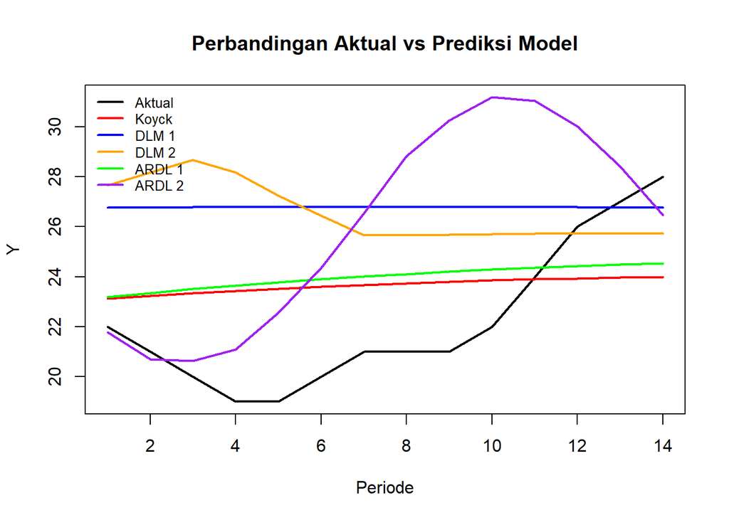

```r
# buat index sederhana untuk sumbu X biar tidak besar
x_index <- 1:nrow(test)

# hitung range Y supaya otomatis
all_values <- c(test$Yt,
                fore.koyck$forecasts,
                fore.dlm$forecasts,
                fore.dlm2$forecasts,
                fore.ardl1$forecasts,
                fore.ardl2$forecasts)
range_y <- range(all_values, na.rm=TRUE)

# plot aktual
plot(x_index, test$Yt, type="l", col="black", ylim=range_y,
     xlab="Periode", ylab="Y",
     main="Perbandingan Aktual vs Prediksi Model",
     lwd=2)

# tambahkan garis model lain
lines(x_index, fore.koyck$forecasts, col="red", lwd=2)
lines(x_index, fore.dlm$forecasts, col="blue", lwd=2)
lines(x_index, fore.dlm2$forecasts, col="orange", lwd=2)
lines(x_index, fore.ardl1$forecasts, col="green", lwd=2)
lines(x_index, fore.ardl2$forecasts, col="purple", lwd=2)

# legenda
legend("topleft",
       legend=c("Aktual","Koyck","DLM 1","DLM 2","ARDL 1","ARDL 2"),
       lty=1, col=c("black","red","blue","orange","green","purple"),
       lwd=2, cex=0.8, bty="n")
```